# Exploring the BRFSS data

Christian Rivera

Introduction to Probability and Data, Duke University

26 November 2016

## Setup

### Load packages

```r
library(ggplot2)
library(dplyr)
```

### Load data

```r
load("brfss2013.RData")
```

## Part 1: Data

The data for this project is from the Behavioral Risk Factor Surveillance System (BRFSS) which is a collection of survey data over the years to measure how behavioral risk factors impact preventable dieseases and other health issues within the population. The data is collected by phone interviewing a randomly sampled population of adults (age 18+) in all states and territories in the United States of America.

Since the data set is quite large (491775 samples) and sampled from the entire population of US residents, I the data set is generalizable and any correlating statistical inferences discovered within the dataset are valid.

Since random assignment was not used, any statistical inferences can not be considered causal, and only correlating.

Personally, my concern with these data collected from phone surveys is that the respondents are usually older than the average population (the respondent skew towards the elderly) which usually occurs because phone surveys only call landline numbers which younger adults do not have. While the BRFSS does survey on randomly sampled cell phone numbers as well, I have a concern that the response percentage from such calls might be lower than that of landline calls and thus skew the data.

## Part 2: Research questions

**Research quesion 1:** Is there a correlation between income level and obesity as measured by the Body Mass Index (BMI)?

As obesisty rates increase across the country, could a rise in obesity be concentrated among certain economic class groups? If this is true, then income level could be an indicator of a heightened chance of obesity. Doctors, health care professionals, and policy makers could then direct anti-obesisty efforts to those economic groups.

In order to determine whether there is a correlation, I will test if there is a correlation between income level and BMI, body mass index. Number of variables used: 3 (income2, bmi5, bmi5cat)

**Research quesion 2:** Is there a wage gap between working men and women in the US when education is factored in?

A point of contention in popular culture is if there is a wage gap that exists in the United States. While some news sources site research suggesting no such gap exists, others report on wage gaps as wide as women earning only 72 cents for every dollar men earn. Controlling for education, does this wage gap exist? With the BRFSS, we can see if such a gap exists because the survey is large, randomly sampled, and does ask for education, gender, and income level. The extent of this analysis is limited because it can only tell if such a gap exists and will not be able to ascertain why it exists. Number of variables used: 3 (income2, sex, educag)

**Research quesion 3:** Are men or women more likely to seek help from a healthcare professional for an emotional problem?

The stereotype in American popular culture is that men are less likely to seek out professional help for emotional problems than women are. Since the BRFSS surveys people on if they have sought help for emotional problems, running a chi squared test on the sample of people responding to this question by gender, would show whether or not the stereotype is accurate. Number of variables used: 2 (sex, mistmnt)

## Part 3: Exploratory data analysis

**Research quesion 1:**

*Is there a correlation between income level and obesity as measured by the Body Mass Index (BMI)?*

As obesisty rates increase across the country, could a rise in obesity be concentrated among certain economic class groups? If this is true, then income level could be an indicator of a heightened chance of obesity. Doctors, health care professionals, and policy makers could then direct anti-obesisty efforts to those economic groups. Whether it is finanicial restrictions on the type of food people in lower income classes can buy or whether it is cultural attribute dependent on class, there are multiple reasons why income and obesity are connected. As such, I cannot claim a causal relationship between the two, but I can see if there is a correlating relationship that could be used as an indicator.

In order to determine whether there is a correlation, I will test if there is a correlation between income level and BMI, body mass index, . Number of variables used: 3 (income2, bmi5, bmi5cat)

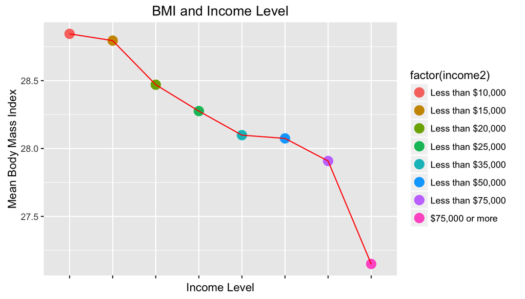

```r
# load the data into a better name.
brf <- brfss2013
rm(brfss2013)

# get rid of null values
brfInc <- filter(brf, !(is.na(X_bmi5)))
brfInc <- filter(brfInc, !(is.na(income2)))

# create a group by of show the averages of all the different groups
brf1 <- summarise(group_by(brfInc, income2), meanBMI = mean(X_bmi5), medBMI = median(X_bmi5), mode = mode(X_bmi5), count = length(X_bmi5))

# the BMI stats for some reason excluded the decimal, so it is added in here
brf1$meanBMI <- brf1$meanBMI / 100

# show the downward trend in average body mass index as income level increases
# first graph is a scatterplot that with an added line to show the downward trend
ggplot(data = brf1, aes(x =income2, y = meanBMI)) +
  geom_point(size = 4, aes(color = factor(income2))) +
  geom_smooth() + stat_summary(fun.y=mean, color = "red", geom="line", aes(group = 1)) +
  theme(axis.text.x = element_blank()) +
  labs(x = "Income Level", y = "Mean Body Mass Index", title = "BMI and Income Level")
```

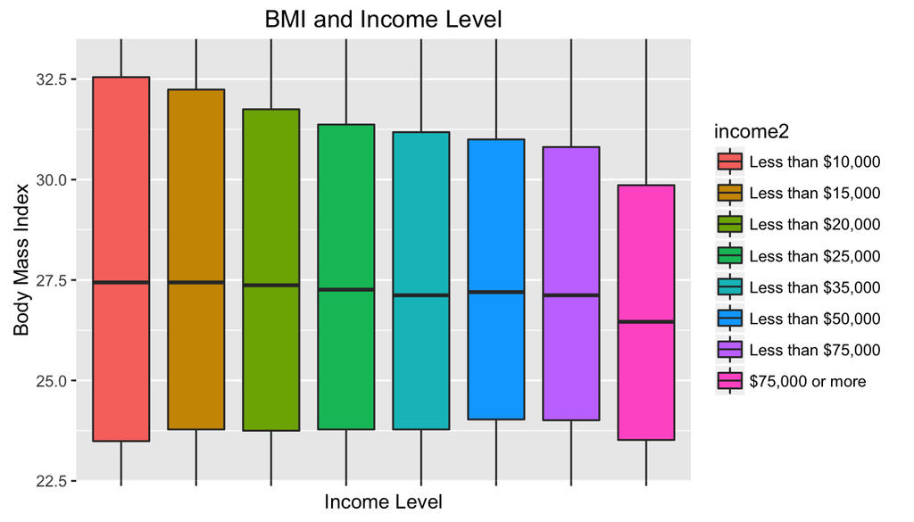

```r
# second graph is a boxplot zoomed in on the actual boxes
ggplot(data = brfInc, aes(factor(income2), X_bmi5/100)) + geom_boxplot(aes(fill = income2)) +
  coord_cartesian(ylim = c(23, 33)) +
  theme(axis.text.x = element_blank()) +
  labs(x = "Income Level", y = "Body Mass Index", title = "BMI and Income Level")
```

```r
# Use statistical tests to see if there is a correlation

# split the data so that one data set is just those making more than $50,000
brfAbove <- filter(brfInc, income2 =="Less than $75,000" | income2 == "$75,000 or more")

#perform a Mann-Whitney U test to determine the p-value
wilcox.test(brfInc$X_bmi5,brfAbove$X_bmi5)
```

```
##
##  Wilcoxon rank sum test with continuity correction
##
## data:  brfInc$X_bmi5 and brfAbove$X_bmi5
## W = 3.6666e+10, p-value < 2.2e-16
## alternative hypothesis: true location shift is not equal to 0
```

As shown above in the graphs, there is a clear inverse relationship between a person’s income level and body mass. People in higher income levels tend to have lower body masse. This is verified by using a Mann-Whitney U test, which though similar to a T-test, does not assume normal distribution in its populations. Running a Mann-Whitney U test comparing the total samples from the BRFSS to just the samples of respondents making $50,000 or more ($50,000 is roughly the average income of a US adult), outputted a a p-value of of p < 2.2 * 10^(-16) which is roughly equal to 0.

Since the p-value is 0 and thus less than 0.05, the null hypothesis is rejected and, as such, there is definitively is a relationship between income level and obesity.

**Research quesion 2:**

*Is there a wage gap between working men and women in the US when education is factored in?*

A point of contention in popular culture is if there is a wage gap that exists in the United States. While some news sources site research suggesting no such gap exists, others report on wage gaps as wide as women earning only 72 cents for every dollar men earn. Controlling for education, does this wage gap exist? With the BRFSS, we can see if such a gap exists because the survey is large, randomly sampled, and does ask for education, gender, and income level. The extent of this analysis is limited because it can only tell if such a gap exists and will not be able to ascertain why it exists. Number of variables used: 3 (income2, sex, educag)

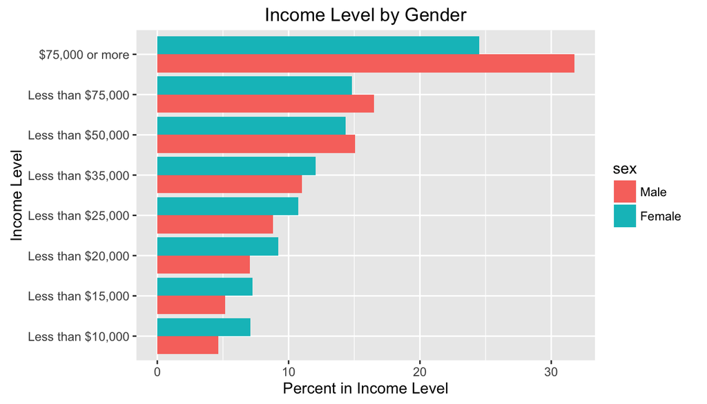

```r
## filter out NA samples that don't have education, sex, and income
brfGender <- filter(brf, !(is.na(sex)))
brfGender <- filter(brfGender, !(is.na(X_educag)))
brfGender <- filter(brfGender, !(is.na(income2)))

############################
#### get the income level distribution by gender
brfGenderGroup2 <- summarise(group_by(brfGender, sex, income2), number = length(sex))
male1 <- filter(brfGenderGroup2, sex == "Male")
female1 <- filter(brfGenderGroup2, sex == "Female")

# assign the percent of each gender representation in each income group
brfGenderGroup2$total <- ifelse(brfGenderGroup2$sex == "Male", sum(male1$number),sum(female1$number))
brfGenderGroup2$percent <- (brfGenderGroup2$number / brfGenderGroup2$total) * 100

# plot the income level by Gender
ggplot(brfGenderGroup2, aes(factor(income2), percent,  fill = sex)) +
  geom_bar(stat="identity", position = "dodge") +
  coord_flip() + labs(y = "Percent in Income Level", x = "Income Level", title = "Income Level by Gender")
```

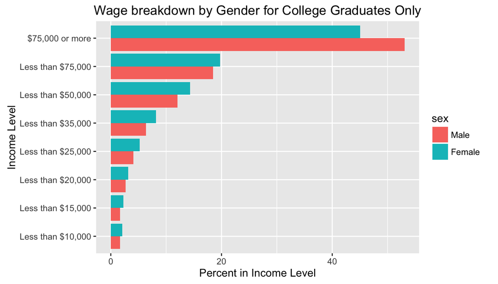

```r
#################

# get the income level distribution for all college/tech school graduates
brfGenderGroup <- summarise(group_by(brfGender, sex, X_educag, income2), number = length(sex))
brfGenderGroup <- filter(brfGenderGroup, X_educag == "Graduated from college or technical school")

# assign the percent of each gender representation in each income group
male1 <- filter(brfGenderGroup, sex == "Male")
female1 <- filter(brfGenderGroup, sex == "Female")
brfGenderGroup$total <- ifelse(brfGenderGroup$sex == "Male", sum(male1$number),sum(female1$number))
brfGenderGroup$percent <- (brfGenderGroup$number / brfGenderGroup$total) * 100

# plot the college grad income level by Gender
ggplot(brfGenderGroup, aes(factor(income2), percent,  fill = sex)) +
  geom_bar(stat="identity", position = "dodge") +
  coord_flip() + labs(y = "Percent in Income Level", x = "Income Level", title = "Wage breakdown by Gender for College Graduates Only")
```

```r
############
## for the spread function
library(tidyr)
# run chi squared tests on income level distribution by gender
brfGenderGroup3 <- summarise(group_by(brfGender, sex, income2), number = length(sex))
brfGenderGroup3 <- spread(brfGenderGroup3, income2, number)
brfGenderGroup3$sex <-NULL
chisq.test(brfGenderGroup3)
```

```
##
##  Pearson's Chi-squared test
##
## data:  brfGenderGroup3
## X-squared = 4930.5, df = 7, p-value < 2.2e-16
```

```r
########
# run chi squared tests on income level distribution by gender for only college/ tech school graduates
brfGenderGroup4 <- summarise(group_by(brfGender, sex, X_educag, income2), number = length(sex))
brfGenderGroup4 <- filter(brfGenderGroup4, X_educag == "Graduated from college or technical school")
brfGenderGroup4 <- spread(brfGenderGroup4, income2, number)
brfGenderGroup4$sex <-NULL
brfGenderGroup4$X_educag <-NULL
chisq.test(brfGenderGroup4)
```

```
##
##  Pearson's Chi-squared test
##
## data:  brfGenderGroup4
## X-squared = 1081.7, df = 7, p-value < 2.2e-16
```

**Research quesion 3:**

*Are men or women more likely to seek help from a healthcare professional for an emotional problem?*

The stereotype in American popular culture is that men are less likely to seek out professional help for emotional problems than women are. Since the BRFSS surveys people on if they have sought help for emotional problems, running a chi squared test on the sample of people responding to this question by gender, would show whether or not the stereotype is accurate. Number of variables used: 2 (sex, mistmnt)

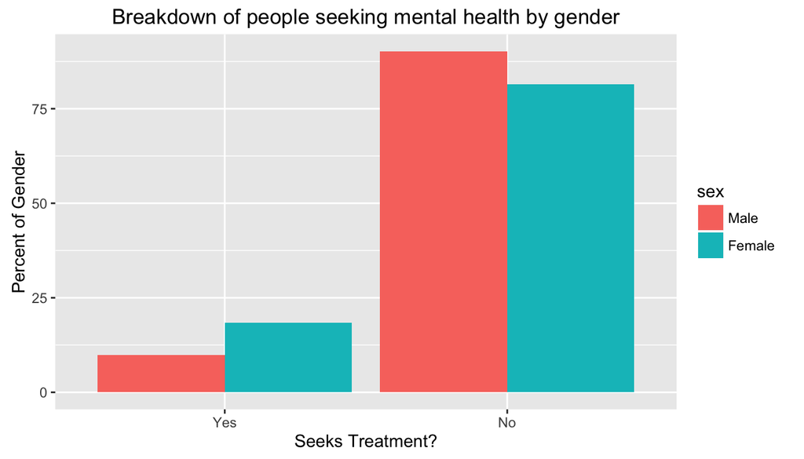

```r
# get rid of null values
brfMental <- filter(brf, !(is.na(sex)))
brfMental <- filter(brfMental, !(is.na(mistmnt)))

# group by gender and anwswer to find the counts for each of th 4 groups
brfMental <- summarise(group_by(brfMental, sex, mistmnt), number = length(sex))

# find sub totals by gender and use it to show percentages of yes and no.
male1 <- filter(brfMental, sex == "Male")
female1 <- filter(brfMental, sex == "Female")
brfMental$total <- ifelse(brfMental$sex == "Male", sum(male1$number),sum(female1$number))
brfMental$percent <- (brfMental$number / brfMental$total) * 100

# show bar plot showing percentages of yes/no answers by gender
ggplot(brfMental, aes(factor(mistmnt),percent, fill = sex)) + geom_bar(stat = "identity", position = "dodge") +
  labs(x = "Seeks Treatment?", y = "Percent of Gender", title = "Breakdown of people seeking mental health by gender")
```

```r
# remove unecessary columns
brfMental$sex <-NULL
brfMental$mistmnt <- NULL

#run Chi-Squared p-value test
chisq.test(brfMental)
```

```
##
##  Pearson's Chi-squared test
##
## data:  brfMental
## X-squared = 12798, df = 6, p-value < 2.2e-16
```

From the results, it appears that neither men nor women tend to seek treatment for for emotional problems however women seek treatment far more often than men (90% of men ignore treatment compared to 81% of women). This is reflected in the Chi-Squared test that shows a p-value of 2.2 * 10^(-16) (again, this is a coincidence this keeps happening), which is infinitismally small and less than 0.05. Since that is the case, the null hypothesis, men and women seek mental help equaly often, is proved false as men seek help statistically less often than women do. Whether this outcome is because of different cultural expectations between the genders, different understandings of what constitutes mental health, men suffer mental health problems at a different rate than women, or another possibility are all hypotheses outside the scope of this statistical experiment.